# [75.06 / 95.58] Organización de Datos Trabajo Práctico 1: Análisis Exploratorio de Datos

**Grupo 30: Datatouille**

- 101055 - Bojman, Camila
- 100029 - del Mazo, Federico
- 100687 - Hortas, Cecilia
- 97649 - Souto, Rodrigo

**https://github.com/FdelMazo/7506-Datos**

**https://kaggle.com/datatouille2018/7506-TP1/**

**https://kaggle.com/datatouille2018/7506-TP1-anexo/**

Presentamos aca un análisis de datos obtenido de usuarios que visitaron www.trocafone.com, un sitio de e-commerce de compra y venta de celulares reacondicionados, con operaciones principalmente en Brasil.

## Set up inicial y curado de datos

```python
import pandas as pd
import numpy as np
import matplotlib.pyplot as plt
import seaborn as sns
import squarify # pip install squarify
import geopandas as gpd #  conda install -c conda-forge geopandas
from wordcloud import WordCloud # conda install -c conda-forge wordcloud
from pySankey import sankey# pip install pySankey
from shapely.geometry import Point
from time import strptime
from math import pi
from PIL import Image
import calendar

import plotly
import plotly.plotly as py # conda install -c conda-forge plotly
import plotly.graph_objs as go
from __future__ import division
plotly.tools.set_credentials_file(username='datatouille', api_key='GJ7Foc8nFWf23VZfzFSK')

%matplotlib inline

df = pd.read_csv('data/events.csv', low_memory=False)
```

```python
sns.set(style="darkgrid")
plt.rcParams['axes.titlesize'] = 30
plt.rcParams['axes.labelsize'] = 24
plt.rcParams['axes.labelweight'] = 'bold'
plt.rcParams['figure.figsize'] = (25,15)
sns.set(font_scale=2)
```

```python
with pd.option_context('display.max_column',0):
  display(df.sample(n=5))
```

|  | timestamp | event | person | url | sku | model | condition | storage | color | skus | search_term | staticpage | campaign_source | search_engine | channel | new_vs_returning | city | region | country | device_type | screen_resolution | operating_system_version | browser_version |
| --- | --- | --- | --- | --- | --- | --- | --- | --- | --- | --- | --- | --- | --- | --- | --- | --- | --- | --- | --- | --- | --- | --- | --- |
| 897335 | 2018-04-20 06:19:30 | searched products | e39426e9 | NaN | NaN | NaN | NaN | NaN | NaN | 2796 | Galaxy | NaN | NaN | NaN | NaN | NaN | NaN | NaN | NaN | NaN | NaN | NaN | NaN |
| 175376 | 2018-05-14 17:17:56 | viewed product | 2e342477 | NaN | 8343.0 | Samsung Galaxy J2 4G Duos | Excelente | 8GB | Dourado | NaN | NaN | NaN | NaN | NaN | NaN | NaN | NaN | NaN | NaN | NaN | NaN | NaN | NaN |
| 863449 | 2018-06-10 18:48:07 | viewed product | db94f19b | NaN | 9902.0 | iPhone 7 | Bom | 128GB | Preto Brilhante | NaN | NaN | NaN | NaN | NaN | NaN | NaN | NaN | NaN | NaN | NaN | NaN | NaN | NaN |
| 346486 | 2018-05-16 01:17:58 | brand listing | 5af7e2bc | NaN | NaN | NaN | NaN | NaN | NaN | 2718,2821,2787,2741 | NaN | NaN | NaN | NaN | NaN | NaN | NaN | NaN | NaN | NaN | NaN | NaN | NaN |
| 492740 | 2018-06-03 00:18:37 | visited site | 7e0fa2b0 | NaN | NaN | NaN | NaN | NaN | NaN | NaN | NaN | NaN | NaN | NaN | Paid | New | São Paulo | Sao Paulo | Brazil | Computer | 1024x600 | Windows 7 | Chrome 66.0 |

### Información general del dataset

```python
bytes_used = df.memory_usage().sum()
print('Memoria usada: {:.2f}MB'.format(bytes_used/1000000))
print('{} atributos y {} registros en el dataframe.\n'.format(df.shape[1],df.shape[0]))
print('Primer registro: {} \nÚltimo registro: {}.'.format(df['timestamp'].min(),df['timestamp'].max()))
```

```
Memoria usada: 186.08MB
23 atributos y 1011288 registros en el dataframe.

Primer registro: 2018-01-01 07:32:26
Último registro: 2018-06-15 23:59:31.
```

```python
describe = df.describe().T
descripcion = pd.read_csv('data/columns-desc.csv',index_col='column')
data = pd.merge(descripcion,describe,left_index=True,right_index=True)
data['null count'] = df.isnull().sum()
data['dtype'] = df.dtypes
with pd.option_context('display.max_colwidth',-1):
    display(data)
```

| column | description | count | unique | top | freq | null count | dtype |
| --- | --- | --- | --- | --- | --- | --- | --- |
| timestamp | Fecha y hora cuando ocurrió el evento. | 1011288 | 793805 | 2018-05-15 15:56:06 | 11 | 0 | object |
| event | Tipo de evento. | 1011288 | 11 | viewed product | 528931 | 0 | object |
| person | Identificador de cliente que realizó el evento. | 1011288 | 27624 | 71492f2b | 2771 | 0 | object |
| url | Url visitada por el usuario. | 82756 | 227 | / | 28323 | 928532 | object |
| sku | Identificador de producto relacionado al evento. | 563838 | 3574 | 2830.0 | 4282 | 447450 | object |
| model | Nombre descriptivo del producto incluyendo marca y modelo. | 564284 | 202 | iPhone 6 | 50916 | 447004 | object |
| condition | Condición de venta del producto. | 563836 | 5 | Bom | 243014 | 447452 | object |
| storage | Cantidad de almacenamiento del producto. | 563836 | 8 | 16GB | 190833 | 447452 | object |
| color | Color del producto. | 563836 | 63 | Preto | 132960 | 447452 | object |
| skus | Identificadores de productos visualizados en el evento. | 221699 | 35310 | 2820,6706,6720,2750,6649,7251,6663,12604,7224,2774,2773,2999 | 594 | 789589 | object |
| search_term | Términos de búsqueda utilizados en el evento. | 48967 | 5851 | Iphone | 1207 | 962321 | object |
| staticpage | Identificador de página estática visitada. | 3598 | 14 | CustomerService | 1528 | 1007690 | object |
| campaign_source | Origen de campaña si el tráfico se originó de una campaña de marketing. | 82796 | 24 | google | 58153 | 928492 | object |
| search_engine | Motor de búsqueda desde donde se originó el evento si aplica. | 50957 | 4 | Google | 50240 | 960331 | object |
| channel | Tipo de canal desde donde se originó el evento. | 87378 | 7 | Paid | 44193 | 923910 | object |
| new_vs_returning | Indicador de si el evento fue generado por un usuario nuevo o por un usuario que regresa al sitio. | 87378 | 2 | Returning | 60480 | 923910 | object |
| city | Ciudad desde donde se originó el evento. | 87378 | 1939 | Unknown | 15819 | 923910 | object |
| region | Región desde donde se originó el evento. | 87378 | 93 | Sao Paulo | 24996 | 923910 | object |
| country | País desde donde se originó el evento. | 87378 | 46 | Brazil | 84308 | 923910 | object |
| device_type | Tipo de dispositivo desde donde se genero el evento. | 87378 | 4 | Smartphone | 44239 | 923910 | object |
| screen_resolution | Resolución de pantalla que se está utilizando en el dispositivo desde donde se genero el evento. | 87378 | 282 | 360x640 | 30009 | 923910 | object |
| operating_system_version | Version de sistema operativo desde donde se origino el evento. | 87378 | 121 | Windows 7 | 19675 | 923910 | object |
| browser_version | Versión del browser utilizado en el evento. | 87378 | 343 | Chrome 66.0 | 22611 | 923910 | object |

**Se sabe que los datos proporcionados son un mero subconjunto de todos los datos de la empresa.**

**¿Cómo se decidió el truncamiento de la base original?**

```python
print('Cantidad de usuarios: {}'.format(df['person'].nunique()))

by_person = df[['event','person']].groupby('person')
con_checkouts = by_person.agg({'event':lambda x: any(y == 'checkout' for y in x)}).sum()['event']

print('Cantidad de usuarios con checkouts: {}'.format(con_checkouts))
```

```
Cantidad de usuarios: 27624
Cantidad de usuarios con checkouts: 27624
```

Después de varias teorías y sus respectivas pruebas, encontramos que todos los usuarios presentes en el set tienen al menos un evento checkout, mostrando que efectivamente la base de datos original se truncó (ya que sería inocente creerse que el 100% de los usuarios que entran al sitio tienen un checkout).

Este dato parece menor pero es muy importante; nos muestra que las conclusiones de este análisis no podrán hacerse sobre el sitio en su totalidad. Por los limites de los datos de entrada todas las conclusiones serán sobre los usuarios que hayan tenido al menos un checkout, en vez de acerca de todos los usuarios del sitio.

### Selección de datos

Pasado el vistazo general a los datos, se pueden transformar datos en sus tipos correspondientes para mejor manejo de estos y para ahorro de memoria.

```python
# Los atributos con pocos valores posibles se pasan a variables categoricas para ahorrar memoria
df['event'] = df['event'].astype('category')
df['condition'] = df['condition'].astype('category')
df['storage'] = df['storage'].astype('category')
df['search_engine'] = df['search_engine'].astype('category')
df['channel'] = df['channel'].astype('category')
df['device_type'] = df['device_type'].astype('category')

# Se pasan los sku a números, para evitar conflictos entre skus iguales pero registrados como 1001 vs 1001.0
df['sku'] = df['sku'].replace({np.nan:0.0, 'undefined':0.0})
df['sku'] = df['sku'].astype('float64')

# El tiempo es mejor manejarlo como tal
df['timestamp'] = pd.to_datetime(df['timestamp'])

# Chequeo
df.info()
```

```
<class 'pandas.core.frame.DataFrame'>
RangeIndex: 1011288 entries, 0 to 1011287
Data columns (total 23 columns):
timestamp                   1011288 non-null datetime64[ns]
event                       1011288 non-null category
person                      1011288 non-null object
url                         82756 non-null object
sku                         1011288 non-null float64
model                       564284 non-null object
condition                   563836 non-null category
storage                     563836 non-null category
color                       563836 non-null object
skus                        221699 non-null object
search_term                 48967 non-null object
staticpage                  3598 non-null object
campaign_source             82796 non-null object
search_engine               50957 non-null category
channel                     87378 non-null category
new_vs_returning            87378 non-null object
city                        87378 non-null object
region                      87378 non-null object
country                     87378 non-null object
device_type                 87378 non-null category
screen_resolution           87378 non-null object
operating_system_version    87378 non-null object
browser_version             87378 non-null object
dtypes: category(6), datetime64[ns](1), float64(1), object(15)
memory usage: 137.0+ MB
```

```python
ahorro = (bytes_used - df.memory_usage().sum())
porcentaje = (ahorro/bytes_used) * 100
print("Memoria ahorrada: {:.4f}MB ({:.2f}%)".format(ahorro/1000000,porcentaje))
```

```
Memoria ahorrada: 42.4723MB (22.83%)
```

### Data Mining

Se agregó el concepto de sesiones. Definimos una sesión como una serie de eventos por usuario, los cuales están todos con menos de 30 minutos de inactividad entre el actual y el anterior.

Todo el código respecto a la generación de sesiones está ubicado en `anexo.ipynb`.

```python
df_sessions = pd.read_csv('data/sessions.csv')
df = df.merge(df_sessions, how='left', left_index=True, right_index=True)
```

```python
session_cols = ['person', 'timestamp', 'time_diff_min', \
        'session_id', 'session_total_events', \
        'session_cumno', 'session_first', 'session_last', \
        'session_conversion', 'session_checkout', 'session_ad']
df[session_cols].head(15)
```

|  | person | timestamp | time_diff_min | session_id | session_total_events | session_cumno | session_first | session_last | session_conversion | session_checkout | session_ad |
| --- | --- | --- | --- | --- | --- | --- | --- | --- | --- | --- | --- |
| 0 | 0004b0a2 | 2018-05-31 23:38:05 | 0.000000 | 0 | 4 | 0 | True | False | False | True | True |
| 1 | 0004b0a2 | 2018-05-31 23:38:05 | 0.000000 | 0 | 4 | 1 | False | False | False | True | True |
| 2 | 0004b0a2 | 2018-05-31 23:38:09 | 0.066667 | 0 | 4 | 2 | False | False | False | True | True |
| 3 | 0004b0a2 | 2018-05-31 23:38:40 | 0.516667 | 0 | 4 | 3 | False | True | False | True | True |
| 4 | 0006a21a | 2018-05-29 13:29:25 | 0.000000 | 0 | 4 | 0 | True | False | False | True | False |
| 5 | 0006a21a | 2018-05-29 13:29:26 | 0.016667 | 0 | 4 | 1 | False | False | False | True | False |
| 6 | 0006a21a | 2018-05-29 13:29:27 | 0.016667 | 0 | 4 | 2 | False | False | False | True | False |
| 7 | 0006a21a | 2018-05-29 13:29:35 | 0.133333 | 0 | 4 | 3 | False | True | False | True | False |
| 8 | 000a54b2 | 2018-04-09 20:12:31 | 0.000000 | 0 | 7 | 0 | True | False | False | False | False |
| 9 | 000a54b2 | 2018-04-09 20:12:31 | 0.000000 | 0 | 7 | 1 | False | False | False | False | False |
| 10 | 000a54b2 | 2018-04-09 20:12:31 | 0.000000 | 0 | 7 | 2 | False | False | False | False | False |
| 11 | 000a54b2 | 2018-04-09 20:12:31 | 0.000000 | 0 | 7 | 3 | False | False | False | False | False |
| 12 | 000a54b2 | 2018-04-09 20:12:53 | 0.366667 | 0 | 7 | 4 | False | False | False | False | False |
| 13 | 000a54b2 | 2018-04-09 20:13:14 | 0.350000 | 0 | 7 | 5 | False | False | False | False | False |
| 14 | 000a54b2 | 2018-04-09 20:13:20 | 0.100000 | 0 | 7 | 6 | False | True | False | False | False |

De las columnas `model`, `operating_system_version` y `browser_version` se pueden extraer datos de la marca, el sistema operativo y el explorador. Estos se usan para generar nuevos dataframes y luego se hace un *left join* de los datos obtenidos.

Todo el código respecto a la creación de nuevos dataframes está ubicado el notebook anexo.

```python
df_brands = pd.read_csv('data/brands.csv')
df = df.merge(df_brands, how='left', on='model')
df['brand'] = df['brand'].astype('category')
sample = df[df['model'].notnull()]
sample[['model','brand']].head()
```

|  | model | brand |
| --- | --- | --- |
| 2 | iPhone 5s | iphone |
| 3 | iPhone 5s | iphone |
| 4 | Samsung Galaxy S8 | samsung |
| 7 | Samsung Galaxy S8 | samsung |
| 13 | Motorola Moto Z Play | motorola |

```python
df_os = pd.read_csv('data/os.csv')
df = df.merge(df_os, how='left', on='operating_system_version')
df['operating_system'] = df['operating_system'].astype('category')
sample = df[df['operating_system_version'].notnull()]
sample[['operating_system_version', 'operating_system']].head()
```

|  | operating_system_version | operating_system |
| --- | --- | --- |
| 1 | Android 6 | android |
| 5 | Android 5.1.1 | android |
| 9 | Windows 10 | windows |
| 16 | Windows 10 | windows |
| 45 | Windows 10 | windows |

```python
df_browsers = pd.read_csv('data/browsers.csv')
df = df.merge(df_browsers, how='left', on='browser_version')
df['browser'] = df['browser'].astype('category')
sample = df[df['browser_version'].notnull()]
sample[['browser_version','browser']].head()
```

|  | browser_version | browser |
| --- | --- | --- |
| 1 | Chrome Mobile 39 | chrome mobile |
| 5 | Android 5.1 | android |
| 9 | Chrome 65.0 | chrome |
| 16 | Chrome 66.0 | chrome |
| 45 | Chrome 65.0 | chrome |

Extracción de información de las fechas.

```python
df['month_number'] = df['timestamp'].dt.month
df['month_name'] = df['month_number'].apply(lambda x: calendar.month_abbr[x])
df['week_day'] = df['timestamp'].dt.weekday
df['week_number'] = df['timestamp'].dt.week
df['week_day_name'] = df['timestamp'].dt.weekday_name
df['day_date'] = df['timestamp'].dt.to_period('D')
df['day_dom'] = df['timestamp'].dt.day
df['hour_count'] = df['timestamp'].dt.hour
df['day_doy'] = df['timestamp'].dt.dayofyear
```

Finalmente, sabiendo que los SKUs se refieren a la combinación única entre modelo, condición de compra, almacenamiento y color, se agrega la columna 'sku_name' para saber específicamente a que dispositivo se refiere.

```python
df['sku_name'] = df['model'] + ' ' + df['storage'].astype(str) + ' ' + df['color'] + ' (' + df['condition'].astype(str) + ')'
df[['sku','sku_name']].head()
```

|  | sku | sku_name |
| --- | --- | --- |
| 0 | 0.0 | NaN |
| 1 | 0.0 | NaN |
| 2 | 2694.0 | iPhone 5s 32GB Cinza espacial (Bom) |
| 3 | 2694.0 | iPhone 5s 32GB Cinza espacial (Bom) |
| 4 | 15338.0 | Samsung Galaxy S8 64GB Dourado (Bom) |

### Limpieza de datos

Tomando como un error de tracking (double tracking en este caso) cuando un usuario compra el mismo celular varías veces en un día, se limpian estos datos duplicados.

```python
df2 = df[df['event'] == 'conversion'][['day_date','person','event','model']]
df2.groupby('person').head()
double_tracking_rows = df2.duplicated(keep='last')
double_tracking_rows = double_tracking_rows[double_tracking_rows]
print('Se limpian {} registros producto de double tracking.'.format(double_tracking_rows.count()))
display(df2[df2.index.isin(double_tracking_rows.index)].sort_values('person').head())

df = df[~df.index.isin(double_tracking_rows.index)]
```

```
Se limpian 205 registros producto de double tracking.
```

|  | day_date | person | event | model |
| --- | --- | --- | --- | --- |
| 20273 | 2018-04-30 | 0562e9d2 | conversion | iPhone 4G |
| 36203 | 2018-05-10 | 0a37e81a | conversion | iPhone 6 |
| 36213 | 2018-05-10 | 0a37e81a | conversion | iPhone 6 |
| 36218 | 2018-05-10 | 0a37e81a | conversion | iPhone 6 |
| 47591 | 2018-03-19 | 0da63237 | conversion | Samsung Galaxy S5 New Edition Duos |

Se limpian los registros en los que el usuario copró un producto sin antes haber pasado por ningún otra etapa previa a la conversión (en una sesión).

```python
df2 = df[(df['session_total_events'] == 1) & (df['event'] == 'conversion')]
print('Se limpian {} registros de conversión directa.'.format(df2['event'].count()))
df = df[~df.index.isin(df2.index)]
```

```
Se limpian 67 registros de conversión directa.
```

## Análisis de eventos

```python
event = df['event']
descripcion = pd.read_csv('data/events-desc.csv',index_col='event')
descripcion['value_counts'] = event.value_counts()
with pd.option_context('display.max_colwidth',0):
    display(descripcion)
```

| event | description | value_counts |
| --- | --- | --- |
| viewed product | El usuario visita una página de producto. | 528931 |
| brand listing | El usuario visita un listado específico de una marca viendo un conjunto de productos. | 98635 |
| visited site | El usuario ingresa al sitio a una determinada url. | 87378 |
| ad campaign hit | El usuario ingresa al sitio mediante una campana de marketing online. | 82827 |
| generic listing | El usuario visita la homepage. | 67534 |
| searched products | El usuario realiza una búsqueda de productos en la interfaz de búsqueda del site. | 56073 |
| search engine hit | El usuario ingresa al sitio mediante un motor de búsqueda web. | 50957 |
| checkout | El usuario ingresa al checkout de compra de un producto. | 33735 |
| staticpage | El usuario visita una página | 3598 |
| conversion | El usuario realiza una conversión comprando un producto. | 900 |
| lead | El usuario se registra para recibir una notificación de disponibilidad de stock para un producto que no se encontraba disponible en ese momento. | 448 |

### Conversion Rate

La primer métrica a analizar y la más importante en un negocio de e-commerce es el **conversion rate**. Siendo una conversión un usuario tomando la acción deseada, en este caso comprar un producto, queremos saber como es la razón entre conversiones y el total de eventos.

```python
conversion_rate_total = (df.loc[df['event']=='conversion'].shape[0] / df.shape[0] )*100
print('Overall conversion rate, from 2018-01-01 to 2018-06-15: {:.3f}%'.format(conversion_rate_total))
```

```
Overall conversion rate, from 2018-01-01 to 2018-06-15: 0.089%
```

Este dato, suelto, no sirve. ¿Cuando es una buena taza de conversión? Cuando es mejor que la anterior!

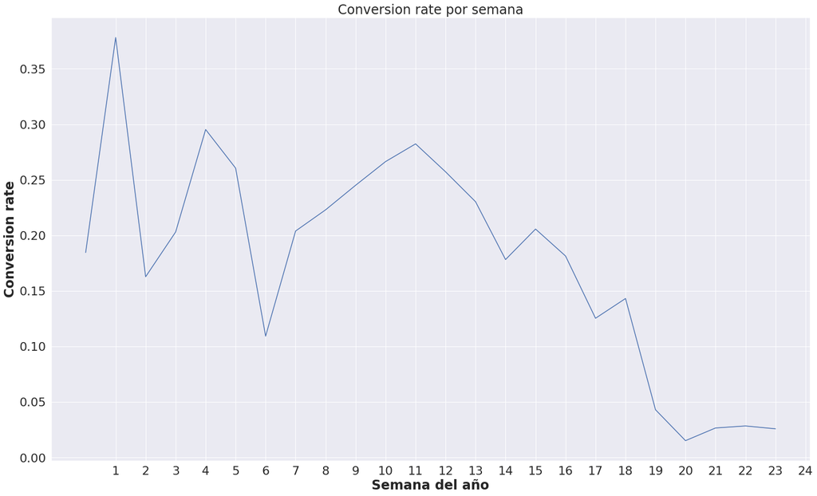

```python
data = df[['event','week_number']]
data = data.groupby(['week_number','event']).agg({'event':'count'})
data = data.rename(columns={'event':'count'})
data = data.reset_index()
data = data.pivot_table(index='week_number', values='count', columns='event')
data = pd.DataFrame(data.to_records())
data['conversion rate'] = ( data['conversion'] / data.sum(axis=1) ) * 100

plt.plot(data['conversion rate'])
plt.ylabel('Conversion rate')
plt.xlabel('Semana del año')
plt.xticks(data['week_number'])
plt.title('Conversion rate por semana')

plt.savefig('informe/figures/010-conversion_rate_semana-lineplot.png')
```

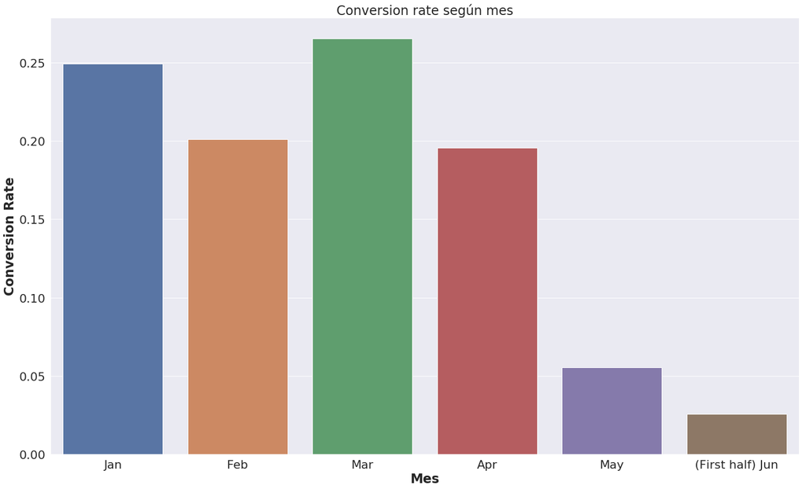

```python
data = df[['event','month_number']]
data = data.groupby(['month_number','event']).agg({'event':'count'})
data = data.rename(columns={'event':'count'})
data = data.reset_index()
data = data.pivot_table(index='month_number', values='count', columns='event')
data = pd.DataFrame(data.to_records())
data['conversion rate'] = ( data['conversion'] / data.sum(axis=1) ) * 100

visu = sns.barplot(x=data['month_number'],y=data['conversion rate'])
visu.set_title('Conversion rate según mes')
visu.set_ylabel('Conversion Rate')
visu.set_xlabel('Mes')
visu.set_xticklabels(['Jan', 'Feb', 'Mar', 'Apr', 'May', '(First half) Jun'])

plt.savefig('informe/figures/011-conversion_rate_mes-barplot.png')
```

Lo que se puede ver en ambos gráficos es que los primeros 4 meses del año hubo un conversion rate bastante estable, y luego una súbita baja en mayo. En las semanas de mayo a junio se ve que hay indicios de un incremento. Al no haber datos de todo el mes de junio, no se pueden hacer más conclusiones pasada la semana 24.

### ¿Cuál es el evento más frecuente?

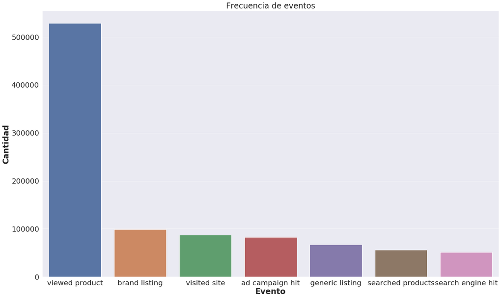

```python
orden = event.value_counts().head(7).index
visu = sns.countplot(x='event',data=df,order=orden)
visu.axes.set_title('Frecuencia de eventos')
visu.set_xlabel("Evento")
visu.set_ylabel("Cantidad")

plt.savefig('informe/figures/02-eventos-barplot.png')
```

El evento con mas hits es el de ver un producto. Esto tiene sentido ya que trocafone es una plataforma de e-commerce y ver productos es su principal función como sitio.

### ¿Cómo evolucionan los eventos a través el tiempo?

Lo siguiente que nos preguntamos es si aumentaron los productos vistos, los checkouts y las compras en el transcurso del primer semestre del 2018.

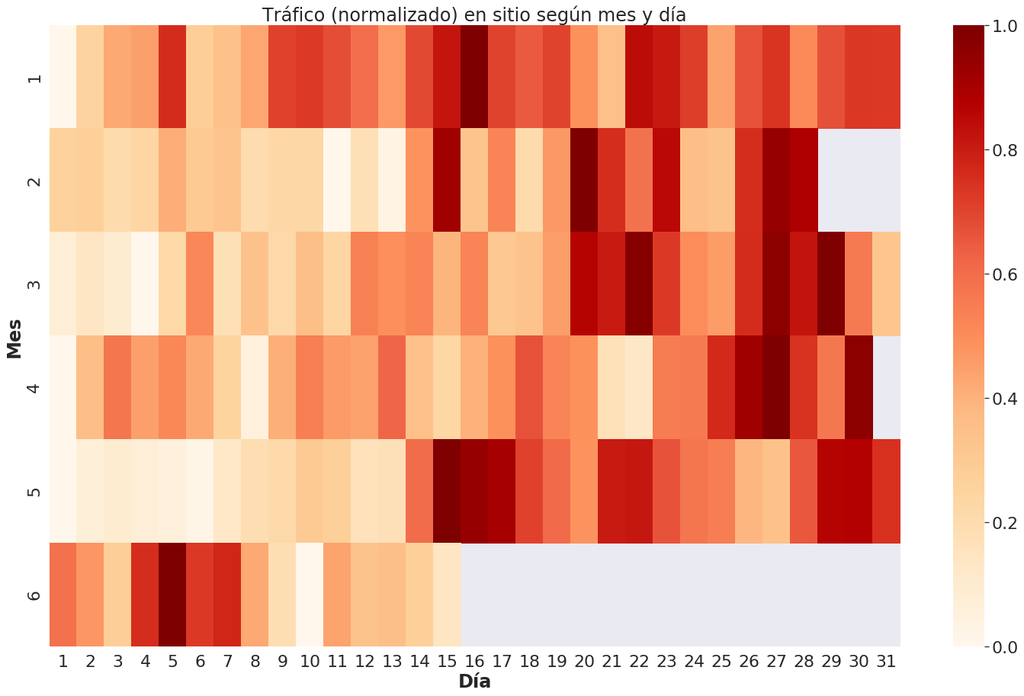

```python
data = df.pivot_table(index='day_dom',columns='month_number', values='event', aggfunc='count')
data = ((data-data.min()) / (data.max() - data.min()))

visu = sns.heatmap(data.T,  cmap="OrRd")
visu.set_title("Tráfico (normalizado) en sitio según mes y día")
visu.set_xlabel("Día")
visu.set_ylabel("Mes")

plt.savefig('informe/figures/030-eventos_segun_mes-heatmap.png')
```

Como se puede ver, no hay relación directa entre dia del mes y mayores visitas al sitio. Se podría decir que la segunda quincena tiene más visitas que la primera, pero las magnitudes no son lo suficientemente distintas como para argumentar esto.

Es importante que este gráfico este normalizado para poder encontrar patrones y no simplemente ver como el mes con más eventos es simplemente el mes con más eventos por día.

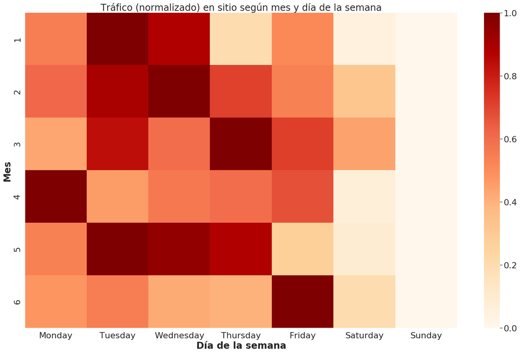

```python
data = df.pivot_table(index='week_day',columns='month_number', values='event', aggfunc='count')
data.index = ['Monday', 'Tuesday', 'Wednesday', 'Thursday', 'Friday', 'Saturday', 'Sunday']
data = ((data-data.min()) / (data.max() - data.min()))

visu = sns.heatmap(data.T,  cmap="OrRd")
visu.set_title('Tráfico (normalizado) en sitio según mes y día de la semana')
visu.set_xlabel('Día de la semana')
visu.set_ylabel('Mes')

plt.savefig('informe/figures/031-eventos_segun_dow-heatmap.png')
```

Se puede observar en el gráfico que los días de mayor tráfico son los días laborales mientras que el fin de semana los usuarios visitan notoriamente menos la página.

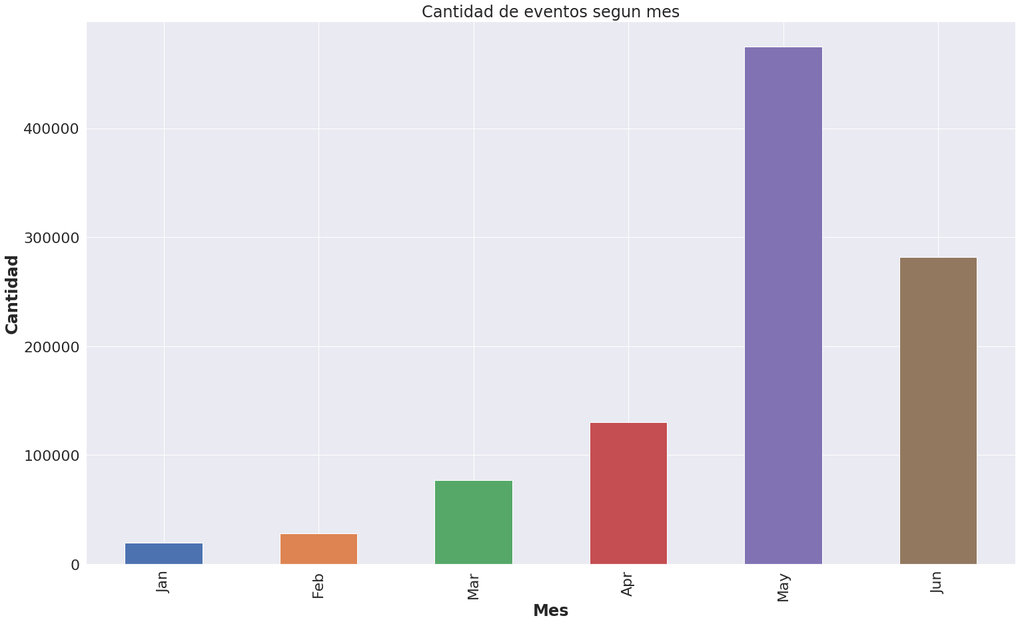

```python
month_name = ['Jan', 'Feb', 'Mar', 'Apr', 'May', 'Jun']
month_counts = df.groupby('month_name').count()
month_counts = month_counts.loc[month_name]
visu = month_counts['event'].plot(kind='bar')
visu.axes.set_title('Cantidad de eventos segun mes')
visu.set_xlabel('Mes')
visu.set_ylabel("Cantidad")

plt.savefig('informe/figures/032-eventos_segun_mes-barplot.png')
```

Como se puede ver, mayo y junio tienen considerablemente más visitas que el resto de los meses. Y esto es incluso teniendo en cuenta que en junio se registraron la mitad de los días (el último registro del set de datos es el 15 de junio).

Es importante notar como esta evolución es casi inversa a la del conversion rate, mostrando que en mayo si bien no hubo tantas ventas, si aumento mucho la cantidad de visitas.

**¿Por que mayo y junio son los meses de mayor tráfico? ¿Eso implica una mayor cantidad de ventas?**

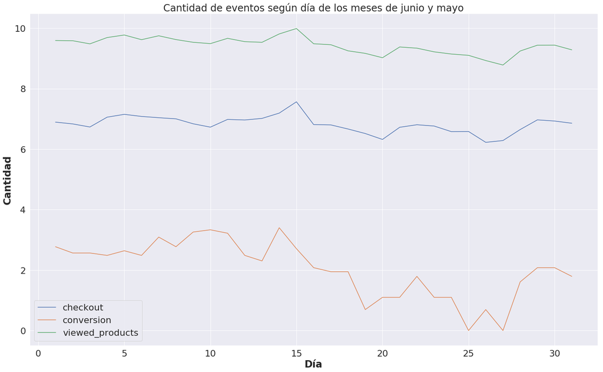

```python
df_top = df.loc[(df['month_name'] == 'May') | (df['month_name'] == 'Jun')]

df_temporal = df_top[['event', 'day_dom']]
df_temporal = df_temporal.loc[(df_temporal['event'] == 'conversion') | (df_temporal['event'] == 'checkout') | (df_temporal['event'] == 'viewed product')]
df_temporal = df_temporal.groupby('day_dom')['event'].value_counts().unstack('event')

visu = plt.plot(np.log(df_temporal))
plt.legend(iter(visu), ('checkout', 'conversion', 'viewed_products'))
plt.title("Cantidad de eventos según día de los meses de junio y mayo")
plt.xlabel("Día")
plt.ylabel("Cantidad")
plt.savefig('informe/figures/033-eventos_mayo_junio_lineplot.png')
```

Es posible concluir que hay un pico entre los días 13 y 16 de los distintos tipos de eventos. Como Trocafone es del país de Brasil y el mayor tráfico proviene de allí, lo cual será verificado posteriormente, se infiere que puede deberse a alguna promoción lanzada en la plataforma o en el mismo país. Esto no puede concluirse con certeza debido a la escasez de información en internet y en la plataforma de promociones pasadas.

### ¿A qué hora se registró la mayor cantidad de conversiones?

```python
df_conversion = df.loc[df['event'] == 'conversion']['hour_count'].value_counts().to_frame().sort_index()
df_checkout = df.loc[df['event'] == 'checkout']['hour_count'].value_counts().to_frame().sort_index()

labels = np.array([0, 1, 2, 3, 4, 5, 6, 7, 8, 9, 10, 11, 12, 13, 14, 15, 16, 17, 18, 19, 20, 21, 22, 23])
angles = [i / float(24) * 2 * pi for i in range(24)]
angles += angles[:1]  #cerrar el círculo

gray = '#999999'
black = '#000000'
orange = '#FD7120'
blue = '#00BFFF'
```

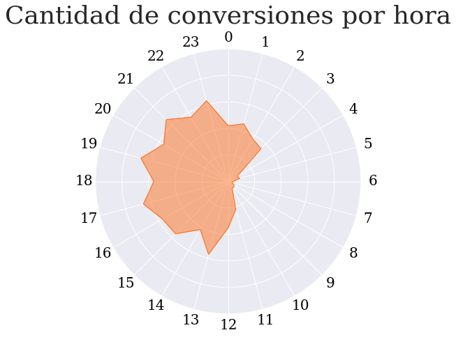

```python
fig=plt.figure(figsize=(7,7))
series = plt.subplot(1, 1, 1, polar=True)

series.set_theta_offset(pi / 2)
series.set_theta_direction(-1)

plt.xticks(angles, labels, color=black, size=20)

plt.yticks([20, 40, 60, 80], ['20', '40', '60', '80'], color=gray, size=2)

plt.ylim(0,100),

series_values = df_conversion.values.flatten().tolist()
series_values += series_values[:1]

series.set_rlabel_position(0)
series.plot(angles, series_values, color=orange, linestyle='solid', linewidth=1)
series.fill(angles, series_values, color=orange, alpha=0.5)
series.set_title('Cantidad de conversiones por hora', y=1.08)
#plt.savefig('informe/figures/040-hours-conversion-radarchart.png')
```

Como es esperable, a la mañana y a la madrugada se registra una muy baja cantidad de compras. Se produce un pico a las 19 hs, hora en la que la mayoría de la gente vuelve del trabajo.

### ¿A qué hora se registró la mayor cantidad de checkouts?

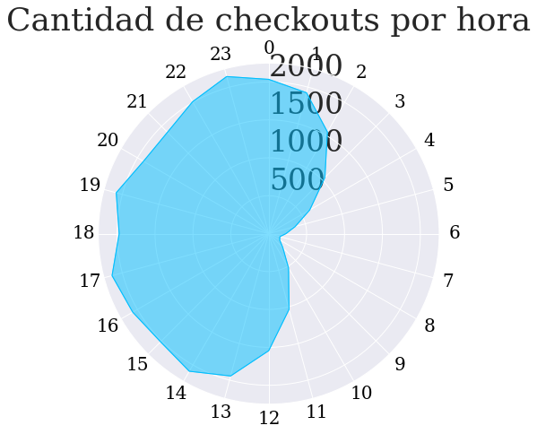

```python
fig=plt.figure(figsize=(7,7))
series = plt.subplot(1, 1, 1, polar=True)

series.set_theta_offset(pi / 2)
series.set_theta_direction(-1)

plt.xticks(angles, labels, color=black, size=20)

#plt.yticks([1000, 1250, 1500, 1750, 2000], ['1000', '1250', '1500', '1750', '2000'], color=gray, size=7)

plt.ylim(0,2250)

series_values = df_checkout.values.flatten().tolist()
series_values += series_values[:1]

series.set_rlabel_position(0)
series.plot(angles, series_values, color=blue, linestyle='solid', linewidth=1)
series.fill(angles, series_values, color=blue, alpha=0.5)
series.set_title('Cantidad de checkouts por hora', y=1.08)
#plt.savefig('informe/figures/041-hours-checkout-radarchart.png')
```

En las primeras 12 hs del día la cantidad de conversiones realizadas es muy baja a contraste de las restantes 12 hs. A diferencia de las conversiones, la cantidad de checkouts realizados mantiene su valor más alto a lo largo de la tarde y la noche. Igualmente se produce un pico a las 19 hs.

### ¿Cuál es la distribución de la cantidad de eventos producidos por usuario en función de los eventos?

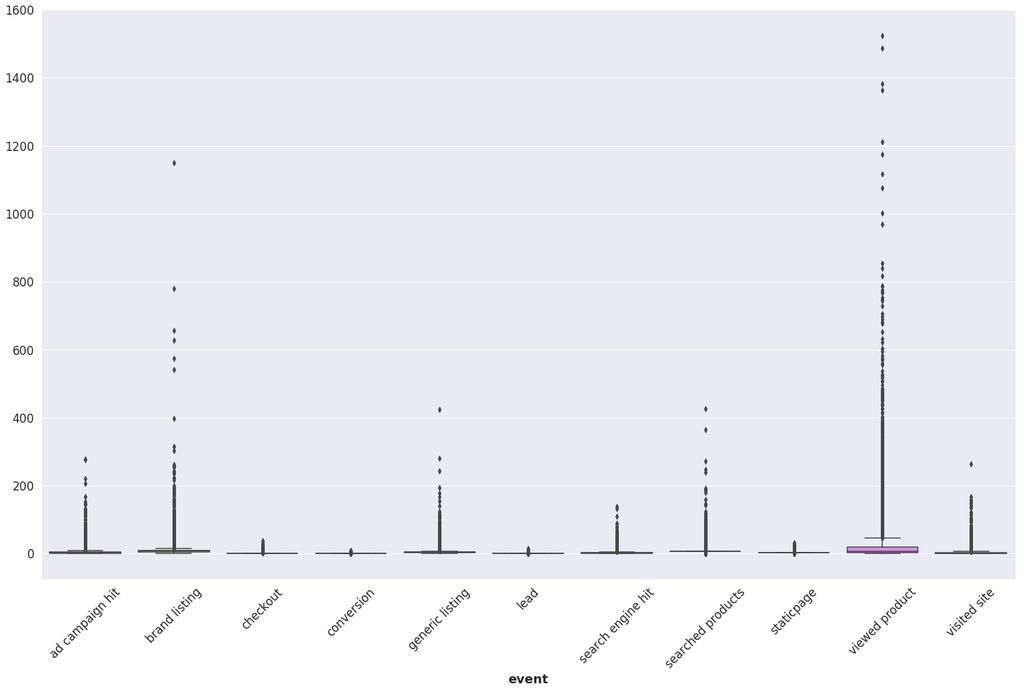

```python
usuarios = df.groupby(['person', 'event'])
usuarios = usuarios.size().unstack(level = 'event')
usuarios = usuarios.fillna(usuarios.mean())
p = sns.boxplot(data=usuarios)
sns.set(font_scale=1.5)
plt.xticks(rotation=45)

#plt.savefig('informe/figures/190-usuarios_eventos-boxplot.png')
```

Como se puede observar el gráfico no es ilustrativo de la respuesta que se desea obtener. Por lo tanto, se propone truncar la éscala del eje y a un valor en el cual se puedan observar las figuras de manera apropiada y representativa.

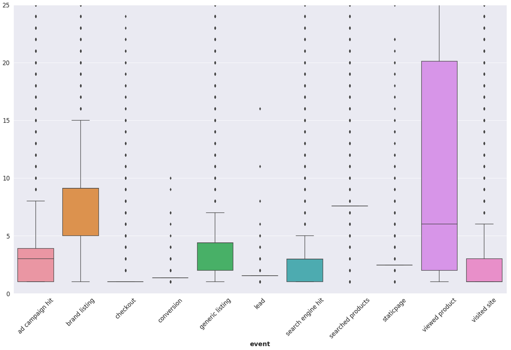

```python
usuarios = df.groupby(['person', 'event'])
usuarios = usuarios.size().unstack(level = 'event')
usuarios = usuarios.fillna(usuarios.mean())
p = sns.boxplot(data=usuarios)
p.axes.set_ylim((0,25))
plt.xticks(rotation=45)

#plt.savefig('informe/figures/191-usuarios_eventos_truncado-boxplot.png')
```

Se propone analizar la cantidad de eventos producidos por usuario en un gráfico de tipo boxplot. Se puede observar que los usuarios suelen más comúnmente ver los productos antes que comprarlos, algo que podía predecirse anteriormente. Lo que puede resultar llamativo es que la cantidad de usuarios que ven productos es mayor a los que los buscan, pero esto se puede explicar por el hecho de que en una búsqueda pueden verse varios productos a la vez y eso cuenta como un solo evento. En cambio, ante el evento viewed products al ver un producto se contabiliza como un solo evento.

## Análisis geográfico

### ¿Desde que países se accede más al sitio?

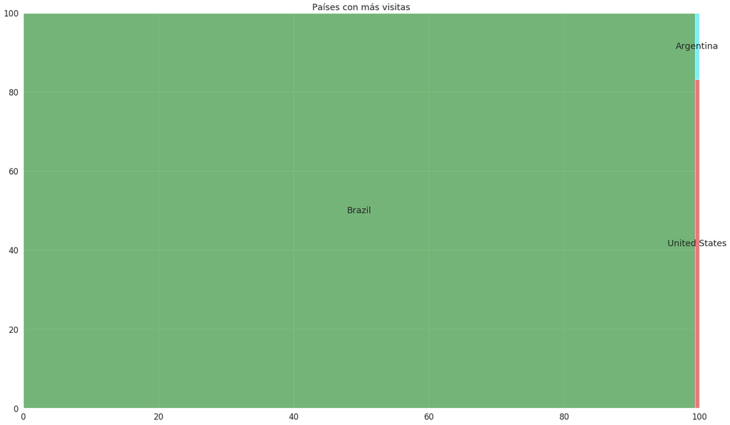

```python
countries = df['country'].value_counts()
countries = countries.drop('Unknown')
data = countries.head(3)

visu = squarify.plot(data, label=data.index, alpha=.5, color=['green','red','cyan'])
visu.set_title('Países con más visitas')

plt.savefig('informe/figures/050-paises_visitas-treemap.png')
```

Al ser Trocafone una empresa que inicialmente radicó en Brasil y llegó a Argentina en 2016 era esperable que Brasil sea el país de mayor tráfico.

Por la amplia diferencia, se separa a Brasil del gráfico y se analiza el tráfico en el resto de los países, para pdoer ver su diferencia en orden y magnitud.

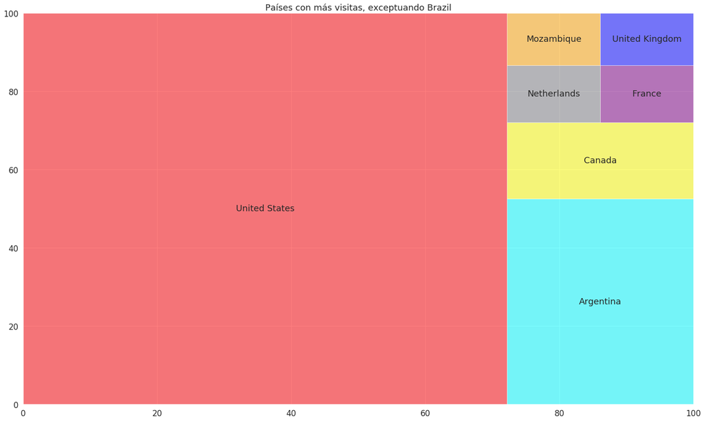

```python
countries = df['country'].value_counts()
countries = countries.drop('Unknown')
countries = countries.drop('Brazil')
data = countries.head(7)

visu = squarify.plot(data, label=data.index, alpha=.5, color=['red','cyan','yellow','grey','purple','orange','blue'])
visu.set_title('Países con más visitas, exceptuando Brazil')

plt.savefig('informe/figures/051-paises_visitas_sin_brazil-treemap.png')
```

### ¿Desde que regiones y ciudades de Brazil se registran más visitas?

**Sacando las longitudes y latitudes de distintas ciudades del mundo, podemos ver que ciudades de Brazil son las que más visitas tienen.**

Con ayuda del módulo geopandas, podemos plotear directamente sobre un mapa.

Las bases de datos adicionales fueron sacadas de http://www.geonames.org/.

Primero, se grafica las regiones, para tener un vistazo general de donde nos encontraremos más visitas. Luego, se ve por ciudad.

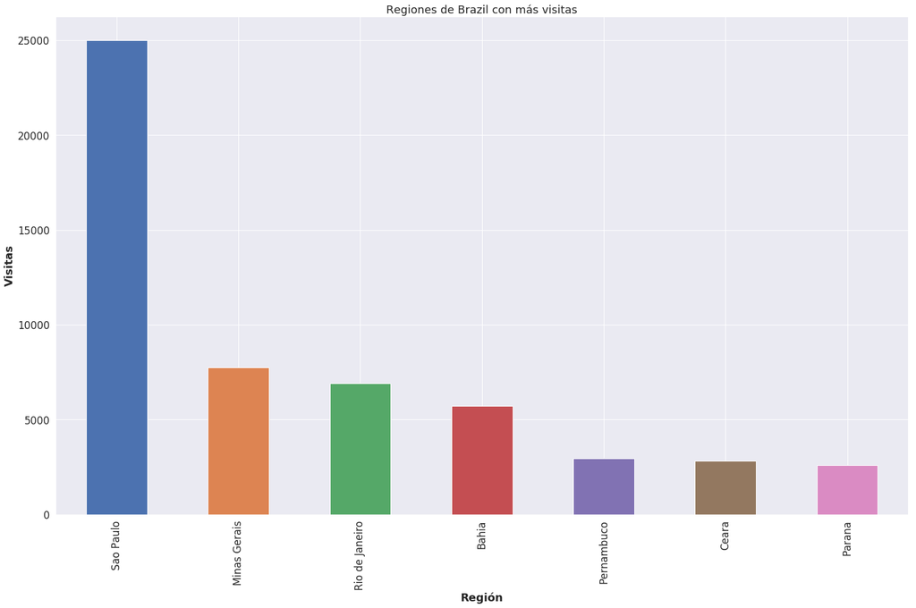

```python
regiones_brasil = df.loc[(df['country'] == 'Brazil')]['region']
data = regiones_brasil.value_counts()
data = data.drop('Unknown')

fig = data.head(7).plot(kind='bar')
fig.axes.set_title('Regiones de Brazil con más visitas')
fig.axes.set_ylabel('Visitas')
fig.axes.set_xlabel('Región')

#plt.savefig('informe/figures/060-regiones_brazil-barplot.png')
```

Viendo que la mayoría de los eventos se registran en la region de San Pablo, Minas Gerais y Rio de Janeiro, se ve que la mayor concentración esta sobre la costa del sur este.

```python
BR = pd.read_csv('data/BR.csv', low_memory=False, sep='\t')
BR = BR[['name','latitude','longitude']]

# Para que geopandas pueda leer bien las latitudes y longitudes, deben ser de la clase Point
BR['coordinates'] = list(zip(BR['longitude'],BR['latitude']))
BR['coordinates'] = BR['coordinates'].apply(Point)
BR.head()
```

|  | name | latitude | longitude | coordinates |
| --- | --- | --- | --- | --- |
| 0 | Tawaribar Rapids | 2.66667 | -59.96667 | POINT (-59.96666999999999 2.66667) |
| 1 | Machpawa Falls | 2.90000 | -59.95000 | POINT (-59.95 2.9) |
| 2 | Kulutuik Fall | 5.08333 | -59.96667 | POINT (-59.96666999999999 5.08333) |
| 3 | Kukuipawa Falls | 2.82548 | -59.95024 | POINT (-59.95024 2.82548) |
| 4 | Kenukawai Mountain | 1.46667 | -58.43333 | POINT (-58.43333000000001 1.46667) |

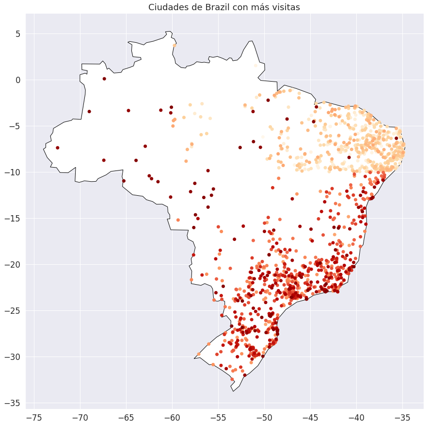

```python
# Se debe hacer un join de los datos que se tienen (nombre de ciudad, cantidad de eventos) y los datos de geonames (nombre de ciudad, punto en el mapa), y esto plotearlo sobre los datos de geopandas (nombre de pais, punto en el mapa mundial)

# Se preparan los datos para el join (inner join de nombre de ciudad (columna name))
ciudades_brazil = df.loc[(df['country'] == 'Brazil')]
data = ciudades_brazil['city'].value_counts()
data = data.drop('Unknown')
data = data.to_frame()
data.reset_index(inplace=True)
data = data.rename(columns={'index':'name','city':'count'})

# Se pasa de un dataframe normal de pandas a uno de geopandas
BRA = gpd.GeoDataFrame(BR, geometry='coordinates')

# Se hace el inner join de ambos sets. Siendo que geonames daba mucha más información de la necesaria, duplicando valores por ciudades, se borran los duplicados
data = BRA.merge(data, on='name')
data = data.drop_duplicates('name')

# Se prepara el 'fondo' del gráfico, siendo este nomás el país. Para esto se usan los datos por defecto de geopandas
world = gpd.read_file(gpd.datasets.get_path('naturalearth_lowres'))
ax = world[world.name=='Brazil'].plot(color='white',edgecolor='black')

visu = data.plot(ax=ax,cmap='OrRd', legend=True)
visu.axes.set_title('Ciudades de Brazil con más visitas')

plt.savefig('informe/figures/061-ciudades_brazil-choropleth.png')
```

Como se preveía en el gráfico anterior, se ve como la mayoría de las visitas se producen sobre la costa sudeste de Brazil.

## Análisis de busquedas

Para lo que respecta a busquedas, hay varias cosas para analizar y encontrar:

1. La mas obvia, ¿qué terminos ingresan los usuarios en el buscador? (columna search term)
   - Esto nos da una visualización rápida de los gustos en crudo de los usuarios. Lo que antojan.
2. ¿Qué productos buscan específicamente, usando la interfaz? (evento searched product)
   - Esta busqueda es un poco más refinada, permitiendonos saber específicamente los productos buscados, en vez de la crudeza de escribir cualquier termino que nos puede plantear el punto anterior.

Si bien tienen un objetivo en comun, difieren sustancialmente los analisis. En el primero se puede ver una vista rápida de marcas/modelos, mientras que en la segunda habrá una idea un poco mas profunda.

### ¿Qué terminos ingresan los usuarios en el buscador?

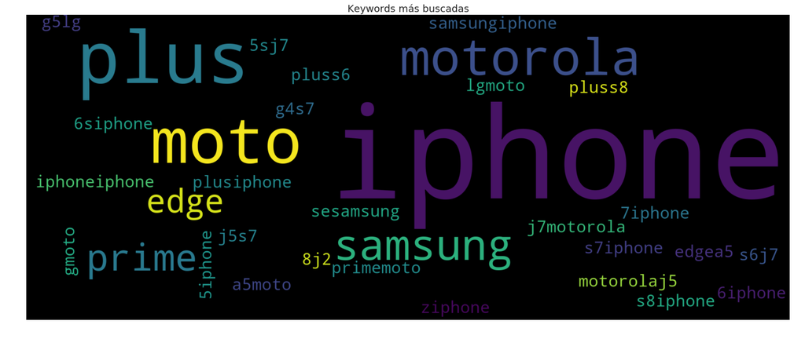

```python
# Buscamos las palabras más buscadas, con un mínimo de 300 busquedas

search_terms = df['search_term'].dropna()
search_terms = search_terms.apply(lambda x: x.lower())
search_terms = search_terms.value_counts()
search_terms = search_terms[search_terms >= 300]

# Para que funcione correctamente el módulo de wordcloud, hay que juntar todas las palabras en el mismo texto.
text = ''
for w,q in zip(search_terms.index,search_terms):
    text += ' '.join([w for x in range(q)])

text = ' '.join([s for s in text.split() if len(s)>2])

wordcloud = WordCloud(width=2000, height=800, margin=0,collocations=False).generate(text)

plt.imshow(wordcloud, interpolation='bilinear')
plt.axis("off")
plt.margins(x=0, y=0)
plt.title('Keywords más buscadas')
plt.show()

wordcloud.to_image().save('informe/figures/07-search_terms-wordcloud.png')
```

Se puede ver que los términos más buscados estan relacionados a las marcas de Motorola, Apple y Samsung.

### ¿Qué productos buscan usando la interfaz?

```python
# Sabemos que el evento searched products refiere a varios SKUs. Spearemos y busquemos especificamente cuales son los más buscados.
searched = df[df['event']=='searched products']
skus_codiciados = searched['skus'].str.split(',').to_frame()
skus_codiciados = skus_codiciados['skus'].apply(pd.Series).unstack().reset_index()
skus_codiciados = skus_codiciados[['level_1',0]]
skus_codiciados.rename(columns={'level_1':'id',0:'sku'}, inplace=True)
skus_codiciados.sample(5)
```

|  | id | sku |
| --- | --- | --- |
| 298162 | 319335 | NaN |
| 652049 | 641109 | 10954 |
| 121969 | 178506 | 6357 |
| 551338 | 847361 | 5015 |
| 664999 | 875015 | NaN |

|  | sku | sku_name |
| --- | --- | --- |
| 388 | 6357.0 | Samsung Galaxy J5 16GB Preto (Bom) |
| 577 | 3371.0 | Samsung Galaxy S6 Flat 32GB Dourado (Bom) |
| 1123 | 6371.0 | Samsung Galaxy J5 16GB Dourado (Bom) |
| 2997 | 6413.0 | Samsung Galaxy J7 16GB Dourado (Bom) |
| 5328 | 2777.0 | Samsung Galaxy S4 i9505 16GB Preto (Bom) |

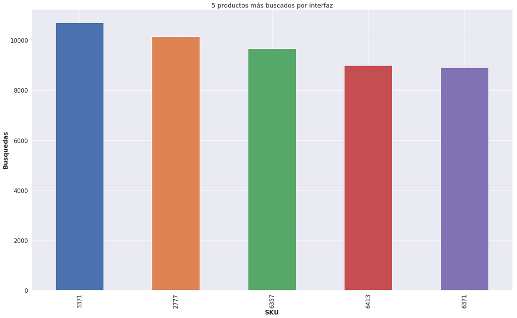

```python
top_5 = skus_codiciados['sku'].value_counts().head(5)
sku_names = df[df['sku'].isin(top_5.index)][['sku','sku_name']].drop_duplicates()

visu = top_5.plot(kind='bar', title ='5 productos más buscados por interfaz')
visu.set_title('5 productos más buscados por interfaz')
visu.set_xlabel('SKU')
visu.set_ylabel('Busquedas')

display(sku_names)
plt.savefig('informe/figures/08-skus_buscados-barplot.png')
```

## Análisis de modelos

Queremos encontrar algun patrón de visita y compra desde el punto de vista del dispositivo y luego ver si en esos patrones hay diferencias según marca o modelo

### ¿Qué eventos tenemos asociados a un modelo?

```python
cronologia = df.loc[df['model'].notnull(), ['model', 'event','condition']]
cronologia['event'].value_counts()
```

```
viewed product       528931
checkout              33733
conversion              900
lead                    448
visited site              0
staticpage                0
searched products         0
search engine hit         0
generic listing           0
brand listing             0
ad campaign hit           0
Name: event, dtype: int64
```

Tomamos como cronología de eventos sobre un modelo:

1. Visitarlo (`viewed product`)
2. Mandar a comprarlo (`checkout`)
3. Efectivamente comprarlo (`conversion`)

### ¿Es el modelo más comprado el más buscado? ¿Es el modelo mas buscado el más llevado al carrito?

```python
# Se descartan los eventos 'lead' porque no influyen en el análisis
cronologia = cronologia.loc[cronologia['event'] != 'lead']

# Comparemos los modelos por los cuales más se opera segun el evento
vistos = cronologia.loc[cronologia['event']=='viewed product']['model'].value_counts().head()
checkouts = cronologia.loc[cronologia['event']=='checkout']['model'].value_counts().head()
comprados = cronologia.loc[cronologia['event']=='conversion']['model'].value_counts().head()

print("Más vistas") ; display(vistos)
print("Más checkouts") ; display(checkouts)
print("Más compras") ; display(comprados)
```

```
Más vistas
```

```
iPhone 6                  47538
iPhone 5s                 42045
iPhone 6S                 36930
iPhone 7                  26330
Samsung Galaxy S7 Edge    23062
Name: model, dtype: int64
```

```
Más checkouts
```

```
iPhone 6             3295
iPhone 5s            2744
iPhone 6S            2308
Samsung Galaxy J5    1918
Samsung Galaxy S7    1234
Name: model, dtype: int64
```

```
Más compras
```

```
Samsung Galaxy J5        69
iPhone 5s                59
iPhone 6                 52
iPhone 6S                26
Motorola Moto G4 Plus    25
Name: model, dtype: int64
```

```python
# Definimos un set de X modelos como los más prominentes, haciendo una combinación de los 7 más vistos, los 5 más por comprar  y los 5 más comprados
modelos_prominentes = set(vistos.index)
modelos_prominentes.update(checkouts.index)
modelos_prominentes.update(comprados.index)

eventos = cronologia.groupby('model')['event'].value_counts().unstack('event')
eventos = eventos[['viewed product', 'checkout', 'conversion']]
eventos = eventos.loc[eventos.index.isin(modelos_prominentes)]
eventos
```

| event model | viewed product | checkout | conversion |
| --- | --- | --- | --- |
| Motorola Moto G4 Plus | 7522.0 | 508.0 | 25.0 |
| Samsung Galaxy J5 | 11036.0 | 1918.0 | 69.0 |
| Samsung Galaxy S7 | 18085.0 | 1234.0 | 14.0 |
| Samsung Galaxy S7 Edge | 23062.0 | 843.0 | 12.0 |
| iPhone 5s | 42045.0 | 2744.0 | 59.0 |
| iPhone 6 | 47538.0 | 3295.0 | 52.0 |
| iPhone 6S | 36930.0 | 2308.0 | 26.0 |
| iPhone 7 | 26330.0 | 1205.0 | 13.0 |

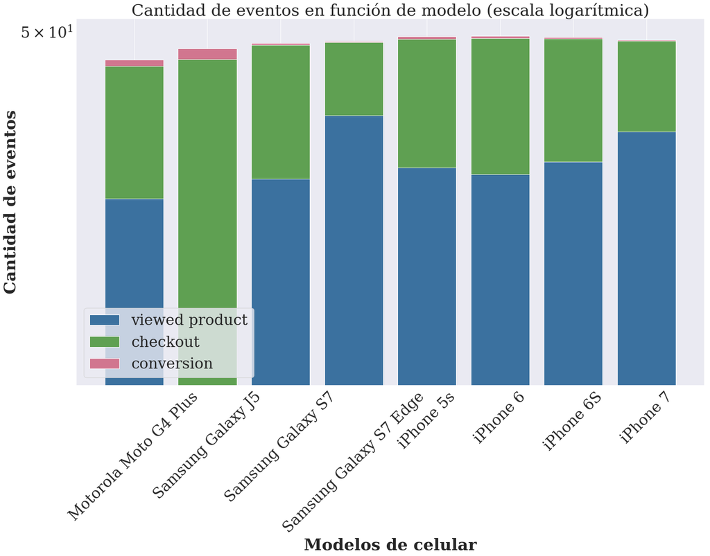

```python
# Paso a porcentajes las columnas
eventos['total'] = eventos.sum(axis=1)
for c in eventos:
    eventos[c+'%'] = ( eventos[c] / eventos['total'] ) * 100

vistos = eventos['viewed product%']
checkouts = eventos['checkout%']
comprados = eventos['conversion%']

plt.bar(vistos.index, vistos, color=sns.xkcd_rgb["muted blue"],log=True)
plt.bar(checkouts.index, checkouts, bottom=vistos, color=sns.xkcd_rgb["muted green"],log=True)
plt.bar(comprados.index, comprados, bottom=vistos+checkouts, color=sns.xkcd_rgb["muted pink"],log=True)
plt.legend(['viewed product','checkout', 'conversion'])
plt.ylabel('Cantidad de eventos')
plt.xlabel('Modelos de celular')
plt.xticks(rotation=45)
plt.title('Cantidad de eventos en función de modelo (escala logarítmica)')
#plt.savefig('informe/figures/090-modelos_eventos-stackedbarplot.png')
```

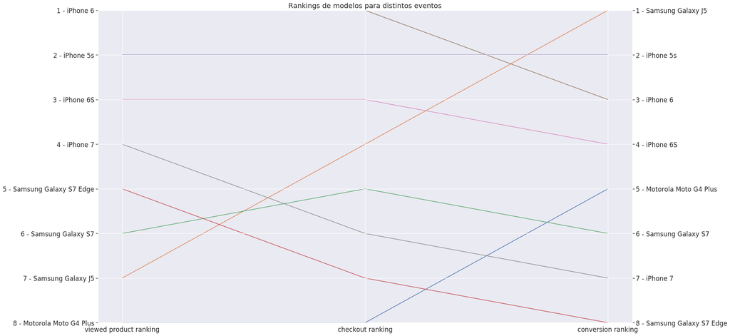

```python
for c in eventos[['viewed product','checkout','conversion']]:
    eventos[c+' ranking'] = eventos[c].rank('index', ascending=False)

rankings = (eventos.filter(regex='ranking')).T
#display(eventos[['viewed product','viewed product ranking','checkout','checkout ranking','conversion','conversion ranking']])
orden = (eventos.sort_values('viewed product ranking', ascending=True)).index
orden = [(str(i+1) + ' - ' + x) for i,x in enumerate(orden)]

orden2 = (eventos.sort_values('conversion ranking')).index
orden2 = [(str(i+1) + ' - ' + x ) for i,x in enumerate(orden2)]

fig = plt.figure()
ax = fig.add_subplot(111)
ax.set_ylim(8)
ax.plot(rankings)
ax.set_yticklabels(orden)

ax2 = ax.twinx()
ax2.set_ylim(8)
ax2.set_yticklabels(orden2)

plt.title('Rankings de modelos para distintos eventos')
#plt.savefig('informe/figures/091-rankings_celulares-rank.png')
```

### ¿Varían los eventos del modelo según su condición? ¿Están los usuarios dispuestos a comprar mejores modelos a menor condición?

Buscamos ahora alguna diferencia en compras de celulares re-acondicionados segun la condición de estos.

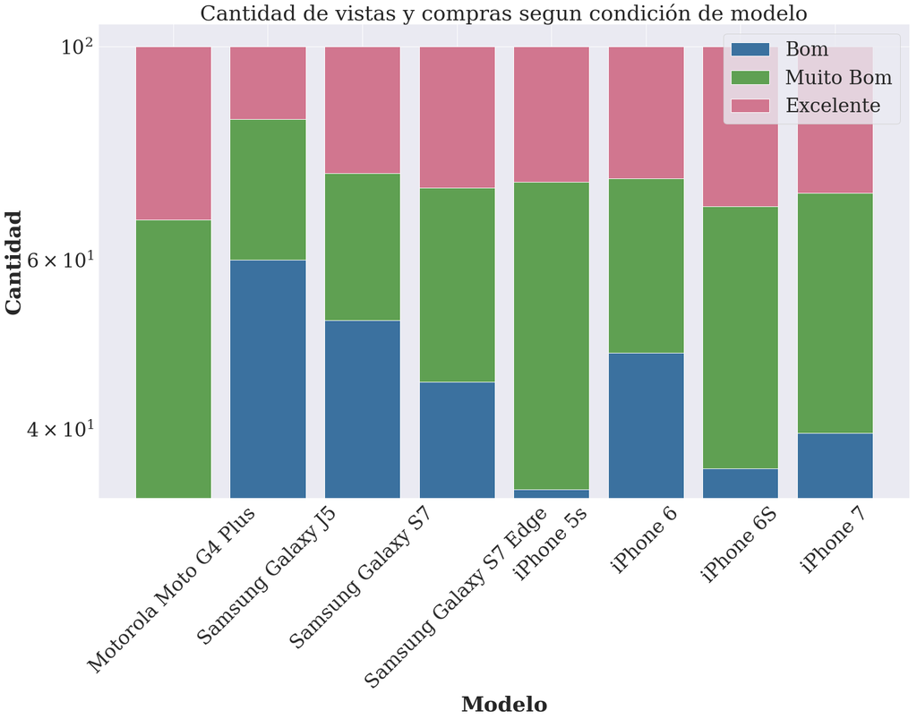

```python
condiciones_analizadas = ['Bom', 'Muito Bom', 'Excelente']

condicion = cronologia.groupby('model')['condition'].value_counts().unstack('condition')
condicion = condicion[condiciones_analizadas]
condicion = condicion.loc[condicion.index.isin(modelos_prominentes)]

condicion['total'] = condicion.sum(axis=1)
for c in condicion:
    condicion[c] = ( condicion[c] / condicion['total'] ) * 100

bom = condicion['Bom']
muito_bom = condicion['Muito Bom']
excelente = condicion['Excelente']

plt.bar(bom.index, bom, color=sns.xkcd_rgb["muted blue"],log=True)
plt.bar(muito_bom.index, muito_bom, bottom=bom, color=sns.xkcd_rgb["muted green"],log=True)
plt.bar(excelente.index, excelente, bottom=bom+muito_bom, color=sns.xkcd_rgb["muted pink"],log=True)
plt.legend(condiciones_analizadas)
plt.ylabel('Cantidad')
plt.xlabel('Modelo')
plt.xticks(rotation=45)
plt.title('Cantidad de vistas y compras segun condición de modelo')
ax.set_yticklabels(orden)


#plt.savefig('informe/figures/10-condicion-stackedbarplot.png')
```

Vemos como nuevamente hay una diferencia substancial entre celulares marca Apple y celulares marca Samsung. Para los Samsungs, los usuarios estan más dispuestos a ver o comprar celulares en peor condición, mientras que para los Apple lo que más se buscan son celulares en mejor condición.

### ¿Como varían los colores de los modelos más prominentes?

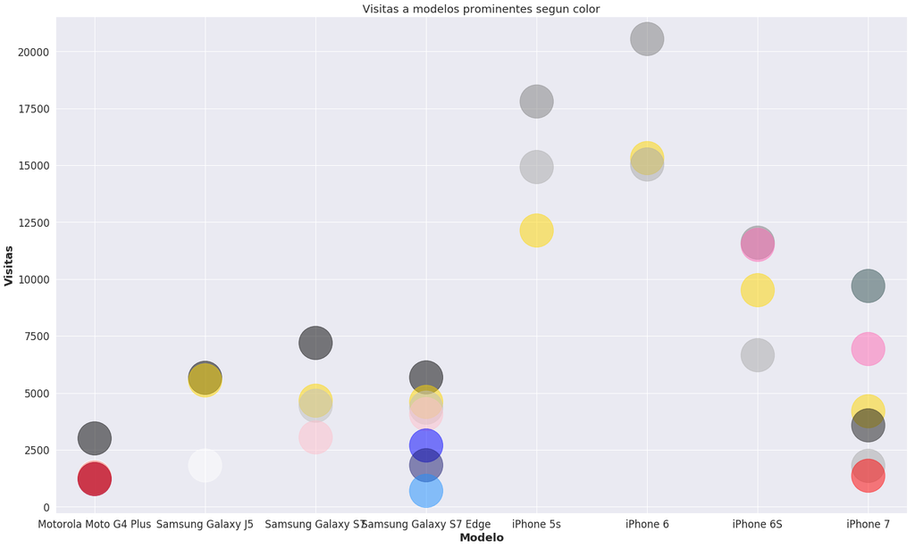

```python
sns_colors = {'Preto':'black', 'Dourado':'gold', 'Branco':'white', 'Prata':'silver', 'Rosa':'pink', 'Azul':'blue',
       'Black Piano':'midnightblue', 'Olympic Edition':'dodgerblue', 'Cinza espacial':'grey', 'Prateado':'darkgray',
       'Ouro Rosa':'hotpink', 'Preto Matte':'darkslategray', 'Preto Brilhante':'k', 'Vermelho':'red', 'Branco Vermelho':'salmon', 'Bambu':'maroon', 'Preto Vermelho':'crimson'}

data = df.loc[df['model'].isin(modelos_prominentes)][['model','color']].groupby('model')['color'].value_counts().to_frame()
data = data.rename(columns={'color':'count'})
data = data.reset_index()
visu = plt.scatter(data['model'], data['count'], s=3000, alpha=0.5,c=data['color'].apply(lambda x:sns_colors[x]))
visu.axes.set_title("Visitas a modelos prominentes segun color")
visu.axes.set_xlabel("Modelo")
visu.axes.set_ylabel("Visitas")

plt.savefig('informe/figures/11-colores-bubbleplot.png')
```

## Análisis de páginas estáticas

```python
df['staticpage'].value_counts()
```

```
CustomerService                      1528
AboutUs                               443
FaqEcommerce                          347
Quiosks                               326
trust-trocafone                       243
galaxy-s8                             167
TermsAndConditionsReturnEcommerce     156
how-to-sell                            96
Conditions                             89
how-to-buy                             86
TermsAndConditionsEcommerce            59
club-trocafone                         46
PrivacyEcommerce                        9
black_friday                            3
Name: staticpage, dtype: int64
```

Podemos ver que la cantidad de visitas a **Customer Service** es mucho mayor a la página de **FAQ**. Para optimizar recursos sería más eficiente intentar de redireccionar el tráfico a FAQ, haciendo más visible los links a la página y de ser necesario mejorándola.

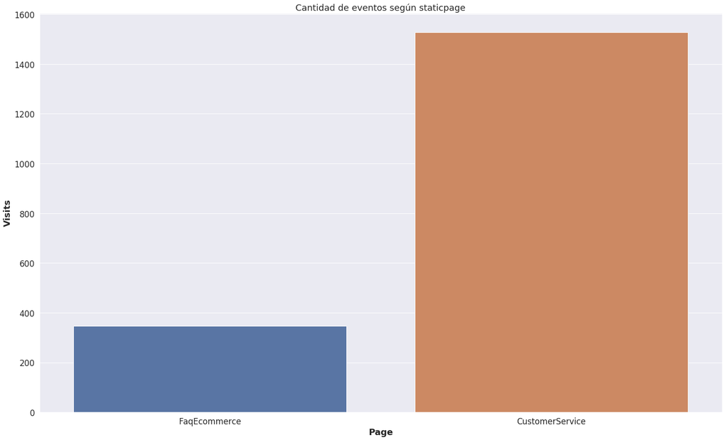

```python
faq_and_service = df[(df['staticpage'] == 'CustomerService') | (df['staticpage'] == 'FaqEcommerce')]['staticpage']
visu = sns.countplot(faq_and_service)
visu.set(xlabel='Page', ylabel='Visits')
visu.axes.set_title('Cantidad de eventos según staticpage')

plt.savefig('informe/figures/12-static_pages-barplot.png')
```

## Análisis de New vs Returning

La intención de este análisis es mostrar que cantidad de usuarios solo ingresan una vez al site. El primer gráfico no nos aporta información, porque todos los usuarios que volvieron a ingresar, en su primera vez fueron **New**.

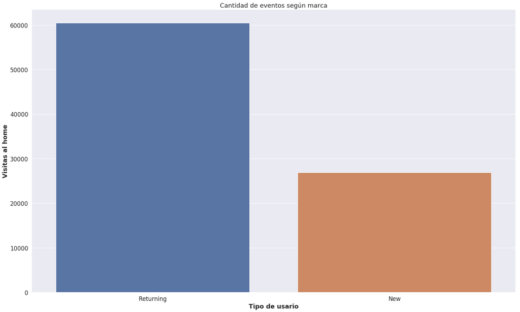

```python
order = df['new_vs_returning'].value_counts().index
visu = sns.countplot(df['new_vs_returning'].dropna(), order=order)
visu.set(xlabel='Tipo de usario', ylabel='Visitas al home')
visu.axes.set_title('Cantidad de eventos según marca')

plt.savefig('informe/figures/130-eventos_new_returning-barplot.png')
```

En este gráfico sí se puede apreciar los valores reales de usuarios que regresan con los que sólo entraron una vez. Para aumentar la tasa de personas que regresan a ĺa página proponemos aumentar el presupuesto en publicidad y mejorar la experiencia de usuario de la home para que provea al usuario una experiencia más amena.

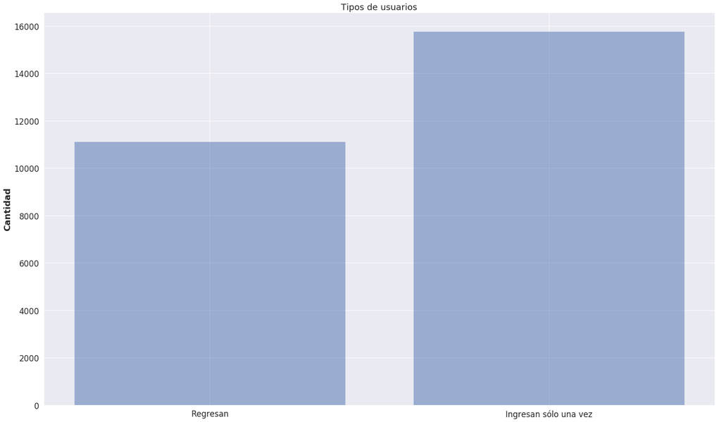

```python
gb = df.groupby(['person', 'new_vs_returning']).agg({'new_vs_returning' : 'size'})
gb = gb.unstack(level='new_vs_returning')
gb = gb['new_vs_returning']
returners_count = gb['Returning'].count()
only_once_count = gb['New'].count() - returners_count

objects = ('Regresan', 'Ingresan sólo una vez')
y_pos = np.arange(len(objects))
type_users_count = pd.Series([returners_count, only_once_count])

plt.bar(y_pos, type_users_count, align='center', alpha=0.5)
plt.xticks(y_pos, objects)
plt.ylabel('Cantidad')
plt.title('Tipos de usuarios')

plt.savefig('informe/figures/131-tipos_usuarios-barplot.png')
plt.show()
```

## Análisis de Brands

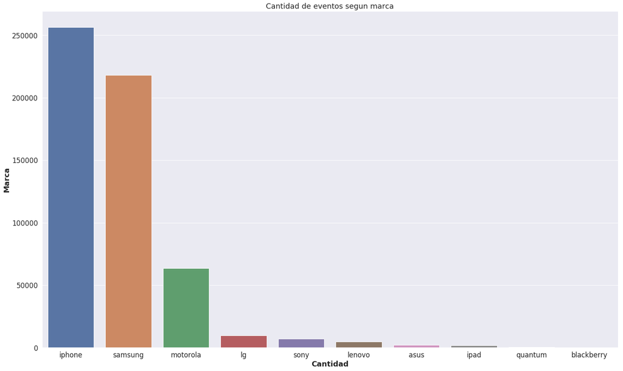

```python
order = df['brand'].value_counts().index
visu = sns.countplot(df['brand'].dropna(), order=order)
visu.axes.set_title('Cantidad de eventos segun marca')
visu.axes.set_xlabel('Cantidad')
visu.axes.set_ylabel('Marca')
sns.set(font_scale=2)

plt.savefig('informe/figures/141-eventos_marca-barplot.png')
```

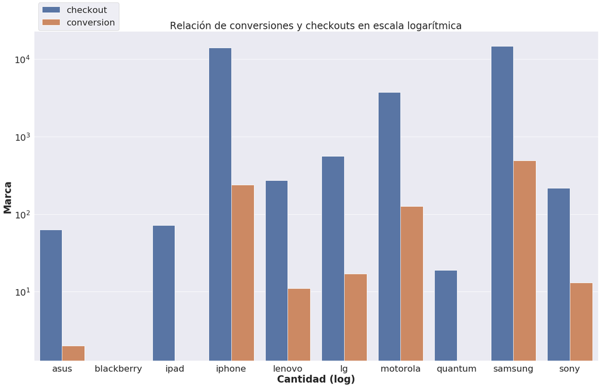

```python
df_conv_by_brand = df.loc[(df['event'] == 'conversion') | (df['event'] == 'checkout')][['event', 'brand']]
# Es necesario para que no me muestre las otras categorías que ya fueron filtradas
df_conv_by_brand['event'] = df_conv_by_brand['event'].astype('object').astype('category')
ax = sns.countplot(x='brand', hue='event', data=df_conv_by_brand)
ax.set_yscale('log')

ax.legend(loc='upper left',bbox_to_anchor=(0, 1.1))
ax.set_xlabel('Cantidad (log)');
ax.set_ylabel('Marca');
ax.set_title('Relación de conversiones y checkouts en escala logarítmica');
sns.set(font_scale=3)

plt.savefig('informe/figures/142-conversiones_checkouts_marca-barplot.png')
```

## Análisis de tipos de dispositivos

Cómo la mayoría del tráfico proviene de smartphones y computadoras, debería dedicarse una mayor cantidad de recursos a desarrollar la aplicación para estos dispositivos y no dedicar mucho tiempo y desarrolladores a las aplicaciones para tablets.

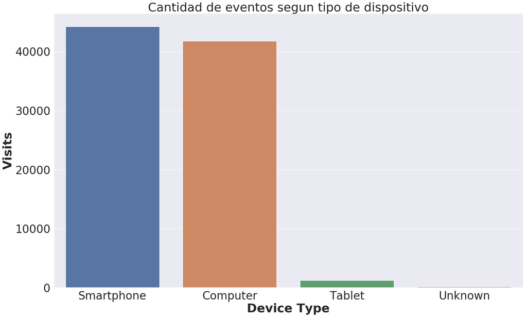

```python
order = df['device_type'].value_counts().index
visu = sns.countplot(df['device_type'].dropna(), order=order)
visu.set(xlabel='Device Type', ylabel='Visits')
visu.axes.set_title('Cantidad de eventos segun tipo de dispositivo')

plt.savefig('informe/figures/150-eventos_tipo-barplot.png')
```

Otra pregunta que nos hacemos es la de si un usuario esta dispuesto a cambiar de marca o no a la hora de ver dispositivos nuevos, es decir, cuan fiel es a su sistema operativo y/o marca.

Por ejemplo, queremos ver si visitantes que entran desde un celular con iOS (sistema operativo de Apple) es mas propenso a ver celulares de Apple y ser fiel a su previa marca o si esta dispuesto a cambiar y ve otro celular.

```python
data = df[['operating_system','brand','person']].groupby('person').first()
data = data.dropna()

data['operating_system'].replace({'mac':'iOS/mac', 'ios':'iOS/mac', 'ubuntu':'linux'},inplace=True)
oss = ['android','windows','iOS/mac','linux']
brands = ['samsung','motorola','iphone']

data = data[(data['brand'].isin(brands)) & (data['operating_system'].isin(oss))]
data.head()
```

| person | operating_system | brand |
| --- | --- | --- |
| 0004b0a2 | android | iphone |
| 0006a21a | android | samsung |
| 000a54b2 | windows | motorola |
| 00184bf9 | windows | iphone |
| 0019c395 | android | samsung |

```
'Diagrama de flujo de fidelidad de usuarios'
```

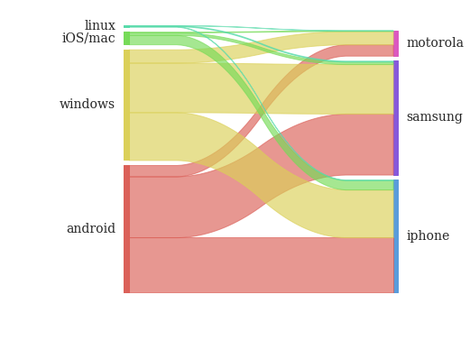

```python
display('Diagrama de flujo de fidelidad de usuarios')
sankey.sankey(data['operating_system'],data['brand'],figure_name='informe/figures/151-os_brands-sankey')
```

Lo que nos encontramos es que los usuarios de iOS/Mac prefieren en su mayoría seguir con su misma marca, mientras que los de Android se dividen bastante uniformemente entre iPhone (y cambiar) y Samsung/Motorola (y ser fieles)

## Análisis de publicidad

### ¿Aumentó Trocafone el presupuesto en publicidad en algún período específico?

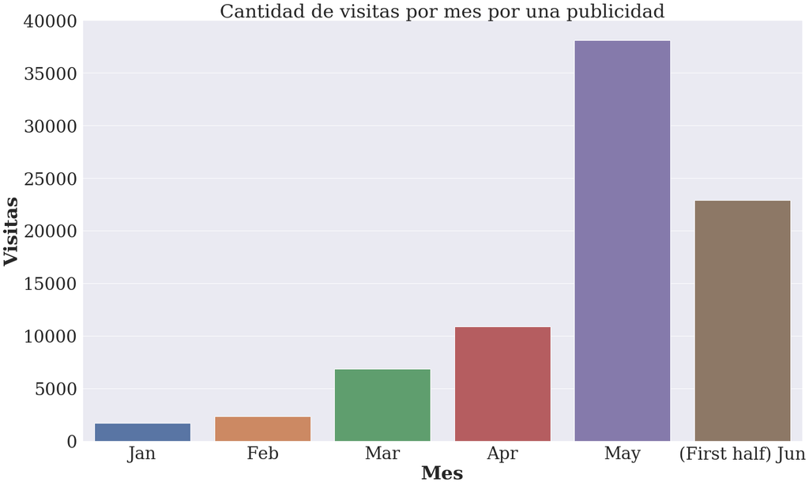

```python
publicitados = df.loc[df['campaign_source'].notnull()][['campaign_source','month_number']]

month_counts = publicitados.groupby('month_number').count()
month_counts = month_counts['campaign_source']
visu = sns.barplot(x=month_counts.index, y=month_counts)
visu.set_title('Cantidad de visitas por mes por una publicidad')
visu.set_ylabel('Visitas')
visu.set_xlabel('Mes')
visu.set_xticklabels(['Jan', 'Feb', 'Mar', 'Apr', 'May', '(First half) Jun'])

plt.savefig('informe/figures/16-presupuesto-barplot.png')
```

No se halló la respuesta buscada ya que la distribución presentada de la cantidad de visitas de campaign_hit remite a la misma distribución de eventos por usuario. Mayo es el mes que notoriamente tiene una mayor cantidad de eventos generalmente pero también de campaign_hits. Por lo tanto concluimos que el gráfico es irrelevante para este tipo de análisis.

### ¿Cuáles son los métodos de publicidad más usados?

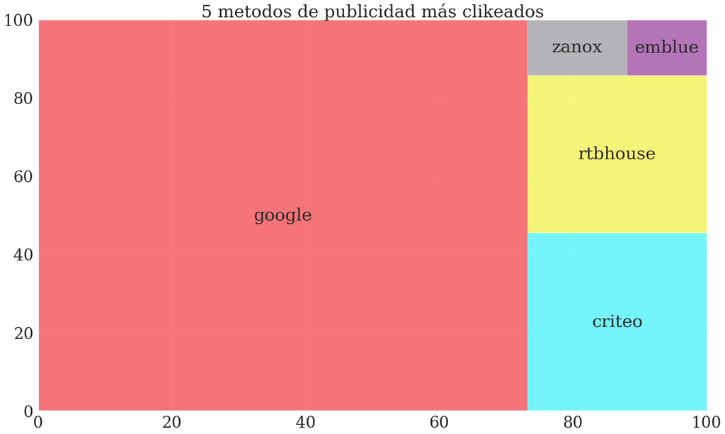

```python
ranking = df['campaign_source'].value_counts()
ranking_visu = ranking.head(5)

visu = squarify.plot(ranking_visu, label=ranking_visu.index, alpha=.5, color=['red','cyan','yellow','grey','purple','orange','blue'])
visu.axes.set_title('5 metodos de publicidad más clikeados')

plt.savefig('informe/figures/170-publicidad_clickeada-barplot.png')
```

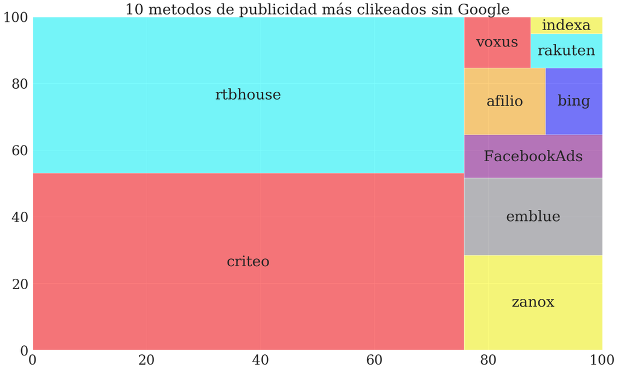

```python
ranking = ranking.drop('google')
ranking_visu2 = ranking.head(10)

ranking_visu2
visu = squarify.plot(ranking_visu2, label=ranking.index, alpha=.5, color=['red','cyan','yellow','grey','purple','orange','blue'])
visu.axes.set_title('10 metodos de publicidad más clikeados sin Google')

plt.savefig('informe/figures/171-publicidad_sin_google-barplot.png')
```

## Análisis de canales de tráfico

Canales de Tráfico:

- Paid: Usuarios que llegan mediante una campaña de marketing.
- Direct: Usuarios que llegan directamente al sitio, sin ayuda externa (por ejemplo, escribiendo directamente la url en el explorador web, un marcador, un link de un documento sin tracking)
- Email: Usuarios que llegan desde un link en un email.
- Organic: Usuarios que llegan desde motores de búsqueda.
- Referral: Usuarios que llegan al sitio desde otro sitio web.
- Social: Usuarios que llegan desde redes sociales.

### Revenue by Traffic Source

Otra importante métrica a analizar del e-commerce es la del revenue by traffic source. Con esto nos referimos a que channel de trafico atrae más consumidores que efectivamente compran.

```python
channels = df[(df['channel'].notnull()) & (df['channel'] != 'Unknown')][['channel','event','person']].drop_duplicates()
channels['total persons'] = channels.groupby('channel')['person'].transform('count')

users = channels[['channel','person']]
total_persons = channels[['channel','total persons']].drop_duplicates()
conversions = df[df['event']=='conversion'][['person']]
total_conversions = users.merge(conversions, how='right').groupby('channel').agg({'person':'count'}).rename(columns={'person':'total conversions'})

channels_conversions = channels.merge(total_conversions,left_on='channel',right_index=True)
channels_conversions = channels_conversions[['channel','total persons','total conversions']].drop_duplicates()
channels_conversions['revenue'] = ( channels_conversions['total conversions'] / channels_conversions['total persons'] ) * 100
channels_conversions
```

|  | channel | total persons | total conversions | revenue |
| --- | --- | --- | --- | --- |
| 1 | Paid | 20025 | 701 | 3.500624 |
| 45 | Organic | 7420 | 480 | 6.469003 |
| 87 | Direct | 5347 | 634 | 11.857116 |
| 118 | Social | 684 | 66 | 9.649123 |
| 127 | Referral | 4167 | 586 | 14.062875 |
| 10786 | Email | 52 | 17 | 32.692308 |

[figure not shown]

```python
revenue_label = list("{:.2f}%".format(x) for x in channels_conversions['revenue'])

barra_total = sns.barplot(x='channel', y='total persons', data=channels_conversions, color=sns.xkcd_rgb["muted blue"])
barra_conversiones = sns.barplot(x='channel', y='total conversions', data=channels_conversions, color=sns.xkcd_rgb["muted green"])
barra_total.set_yscale('log')
barra_conversiones.set_yscale('log')

for i,barra in enumerate(barra_total.patches[:6]):
    height = barra.get_height()
    barra_conversiones.text(barra.get_x() + barra.get_width()/2., height + 10, revenue_label[i], ha='center')

barra_total.set_title('Revenue by Traffic Source (escala logarítmica)')
barra_total.set_ylabel('Cantidad de eventos (log)')
barra_total.set_xlabel('Canal de tráfico')
barra_total.legend(['conversions','total'])

plt.savefig('informe/figures/180-revenue_traffic-boxplot.png')
```

## Funnels de usuarios

Teniendo en cuenta si una sesión comienza por *advertising* o no, se genera un funnel que muestre la proporción de conversiones entre cada paso hasta una *conversion*, y la proporción de los eventos que provienen por publicidad.

```python
dfunnel = df[\
    (df['event'] == 'generic listing') | \
    (df['event'] == 'brand listing') | \
    (df['event'] == 'searched products') | \
    (df['event'] == 'viewed product') | \
    (df['event'] == 'checkout') | \
    (df['event'] == 'conversion') \
]

# color for each segment
colors = ['rgb(63,92,128)', 'rgb(90,131,182)', 'rgb(255,255,255)', 'rgb(127,127,127)', 'rgb(84,73,75)']
colors = ['rgb(63,92,128)', 'rgb(84,73,75)']
```

```python
dfunnel = dfunnel.groupby(['event', 'session_ad']).size().unstack(level='session_ad')
dfunnel.head()
```

| session_ad event | False | True |
| --- | --- | --- |
| brand listing | 84620 | 14015 |
| checkout | 27278 | 6457 |
| conversion | 796 | 104 |
| generic listing | 58727 | 8807 |
| searched products | 48060 | 8013 |

```python
# Se cambió de nombre a las columnas, el orden de las filas y se pasó los valores a escala logarítmica

dfunnel.columns = ['Other', 'Ad']
dfunnel = dfunnel.reindex([\
                 'viewed product', 'checkout', 'conversion'])
dfunnel = np.log(dfunnel)
```

```python
dfunnel
```

| event | Other | Ad |
| --- | --- | --- |
| viewed product | 13.009192 | 11.319729 |
| checkout | 10.213836 | 8.772920 |
| conversion | 6.679599 | 4.644391 |

```python
total = [sum(row[1]) for row in dfunnel.iterrows()]
```

```python
n_phase, n_seg = dfunnel.shape
```

```python
plot_width = 500
unit_width = plot_width / total[0]

phase_w = [int(value * unit_width) for value in total]

# height of a section and difference between sections
section_h = 100
section_d = 10

# shapes of the plot
shapes = []

# plot traces data
data = []

# height of the phase labels
label_y = []
```

```python
height = section_h * n_phase + section_d * (n_phase-1)

# rows of the DataFrame
df_rows = list(dfunnel.iterrows())

# iteration over all the phases
for i in range(n_phase):
    # phase name
    row_name = dfunnel.index[i]

    # width of each segment (smaller rectangles) will be calculated
    # according to their contribution in the total users of phase
    seg_unit_width = phase_w[i] / total[i]
    seg_w = [int(df_rows[i][1][j] * seg_unit_width) for j in range(n_seg)]

    # starting point of segment (the rectangle shape) on the X-axis
    xl = -1 * (phase_w[i] / 2)

    # iteration over all the segments
    for j in range(n_seg):
        # name of the segment
        seg_name = dfunnel.columns[j]

        # corner points of a segment used in the SVG path
        points = [xl, height, xl + seg_w[j], height, xl + seg_w[j], height - section_h, xl, height - section_h]
        path = 'M {0} {1} L {2} {3} L {4} {5} L {6} {7} Z'.format(*points)

        shape = {
                'type': 'path',
                'path': path,
                'fillcolor': colors[j],
                'line': {
                    'width': 1,
                    'color': colors[j]
                }
        }
        shapes.append(shape)

        # to support hover on shapes
        hover_trace = go.Scatter(
            x=[xl + (seg_w[j] / 2)],
            y=[height - (section_h / 2)],
            mode='markers',
            marker=dict(
                size=min(seg_w[j]/2, (section_h / 2)),
                color='rgba(255,255,255,1)'
            ),
            text="Segment : %s" % (seg_name),
            name="Value : %d" % (dfunnel[seg_name][row_name])
        )
        data.append(hover_trace)

        xl = xl + seg_w[j]

    label_y.append(height - (section_h / 2))

    height = height - (section_h + section_d)
```

```python
# For phase names
label_trace = go.Scatter(
    x=[-350]*n_phase,
    y=label_y,
    mode='text',
    text=dfunnel.index.tolist(),
    textfont=dict(
        color='rgb(200,200,200)',
        size=9
    )
)

data.append(label_trace)

# For phase values (total)
value_trace = go.Scatter(
    x=[350]*n_phase,
    y=label_y,
    mode='text',
    text=total,
    textfont=dict(
        color='rgb(200,200,200)',
        size=9
    )
)
```

```python
layout = go.Layout(
    title="<b>Funnel (log) [Otro:Azul | Ad:Marrón]</b>",
    titlefont=dict(
        size=20,
        color='rgb(230,230,230)'
    ),
    hovermode='closest',
    shapes=shapes,
    showlegend=False,
    paper_bgcolor='rgba(44,58,71,1)',
    plot_bgcolor='rgba(44,58,71,1)',
    xaxis=dict(
        showticklabels=False,
        zeroline=False,
    ),
    yaxis=dict(
        showticklabels=False,
        zeroline=False
    )
)

fig = go.Figure(data=data, layout=layout)
py.iplot(fig)
#plotly.io.write_image(fig,'informe/figures/200-advertisement-funnel.png')
```

[interactive chart not shown]